# Лабораторная работа № 1.

## Годоскоп из стримерных трубок.

### Кафедра физики ускорителей

Вероника Бояркина, Вячеслав Федоров, Анна Шуклина

## Теория

### Стримерный режим газового разряда

Трубки, работающие в ограниченном стримерном режиме (стримерные трубки), — одна из разновидностей детекторов заряженных частиц, широко применяющаяся в настоящее время в экспериментах по физике высоких энергий. Трубка состоит из цилиндрического (или другой формы) катода, по оси которого натя- нута тонкая проволочка-анод. При малых напряжениях такой прибор работает в режиме ионизационной камеры. При увеличении напряжения происходит переход к пропорци- ональному режиму, затем к гейгеровскому разряду и искровому пробою. В конце 60-х годов было обнаружено, что при определенном подборе газовой смеси и диаметра анодной проволочки, гейгеровский механизм не работает, а развитие разряда происходит другим способом. Новый механизм газового разряда получил название стримерного. Стримерный режим отличается большими (порядка 1 мА) и короткими (порядка 100 нс) импульсами и обычно достигается в камерах и счетчиках с относительно толстыми (порядка 100 мкм) анодными проволочками при больших концентрациях органических добавок, хорошо по- глощающих фотоны.

### Стримерные трубки как координатные детекторы

Часто, кроме самого факта прохождения частицы, требуется еще измерить координату прохождения частицы через детектор. В настоящее время развито много методик для определения координаты в стримерных трубках. К наиболее известным можно отнести следующие:

- определение координаты в режиме ДА-НЕТ (по номеру сработавшей трубки);
- определение координаты вдоль проволочки по центру тяжести наведенного заряда на катодные полоски, расположенные перпендикулярно к проволочке;
- определение координаты вдоль проволочки по делению заряда на разных концах трубки;
- определение координаты вдоль проволочки по разности времен прихода сигнала на разные концы трубки;
- определение координаты в перпендикулярном к проволочке направлении по времени дрейфа ионизации до проволочки;

Большая амплитуда сигнала, хорошие временные характеристики стримерного сигнала позволяют упрощать регистрирующую электронику, снижать требования к чувствитель- ности, порогам, стабильности.

## Описание работы

### Измерение продольной координаты методом временной разности

В лабораторной работе съем продольной координаты со стримерных трубок организован с помощью методики разности времен. Координата вдоль проволочки линейно зависит от измеренной разности времен. Коэффициент пропорциональности — скорость распро- странения сигнала по трубке, деленная пополам (15 см/нсек, или 6.7 псек/мм). В случае наполненного газом коаксиального волновода эта величина практически совпадает с по- ловиной скорости света в вакууме. Пространственное разрешение детектора определяется временным разрешением электроники.

### Годоскоп

В лабораторной работе используется годоскоп из четырех модулей стримерных трубок Длина трубок годоскопа — 1 метр. Каждый модуль состоит из двух слоёв трубок по 4 шту- ки в каждом. На торцах модуля установлены платы для разведения высокого напряжения и калибровки каналов. Далее, на одном из торцов установлены два канала электроники (четыре дискриминатора и два экспандера). На модуле имеется панель, на которой рас- положены сигнальный, высоковольтный и три калибровочных разъема, разъем питания электроники и две газовые оливки для подачи газа (все трубки соединены по газу после- довательно). Сверху торцы прикрыты кожухами.

Модули продуты газовой смесью аргон:н-пентан (3:1) и после этого герметизированы. Рабочее напряжение 4000 В. Плато счетной характеристики 3600–4600 В. Характерные параметры стримерного сигнала для рабочего напряжения: средняя амплитуда на входе дискриминатора 200 мВ, длительность сигнала 200 нсек, фронт 7 нсек.

Для системы сбора данных с годоскопа используется стандарт КАМАК. Сигналы с экспандеров поступают на преобразователь(ECL-NIM)-разветвитель (далее ПР). ПР формирует сигналы “старт” и “стоп” для ВЦП, а также по одному дополнительному сигналу на каждый канал. Сигнал “старт” поступает на цифровую линию задержки (ЛЗ, 500 нсек) и далее на вход “старт” ВЦП. Дополнительные сигналы с каналов 1, 2, 7, 8 (нижний и верхний модули) идут на схему совпадений (СС) и используются для формирования сигнала (на формиро- вателе импульсов — ФИ) для запуска ВЦП. Дополнительные сигналы с каналов 3, 4, 5, 6 идут на счетчик импульсов (СЧ) для контроля загрузок. При наборе статистики на СС устанавливается маска первого выхода, соответствующая совпадению нижнего и верхне- го модулей. Второй выход СС маскируется на сигнал генератора. Сигнал с него подан на СЧ. Третий и четвертый выходы маскируются таким образом, чтобы они соответствовали каналам 1 и 7 годоскопа. Сигналы с них поданы на СЧ.

Для калибровок используется генератор коротких импульсов ГЕКИ. Он запускается с помощью генератора логических импульсов (ГЛИ) и требует дополнительного питания от источника +300 В. ГЕКИ имеет встроенный аттенюатор для регулировки амплитуды выходного сигнала. Сигнал с ГЕКИ поступает на коммутатор высокой частоты (КВЧ) и при калибровке поочередно подается на все четыре модуля. При этом первый выход СС маскируется на генератор. В крейте также расположены: блок ЦДР - для вывода графической информации, индикатор питания крейта - используется для вывода питания электроники модулей стримерных трубок, высоковольтный источник (ВВИ). Напряжение с ВВИ подается на коробку-разветвитель и далее на четыре модуля.

### Программное обеспечение

Программа для работы с годоскопом называется NUCLAB. Она умеет:

- инициализировать используемые КАМАК блоки,
- калибровать модули стримерных трубок:
- задавать параметры гистограмм,
- выводить гистограммы,
- чистить гистограммы,
- измерять загрузки,
- набирать статистику.

Информация о событии включает:

- считанное с ВЦП время для каждого канала,
- восстановленные X, Y , Z координаты,
- отклонение измеренной координаты от восстановленного трека,
- параметры прямой Z = k · Y + b,
- NW — количество сработавших каналов,
- NT — количество каналов с правдоподобно восстановившейся Z-координатой,
- NP — количество каналов, взятых в восстановление трека.

## Задания

### Измерение эффективности срабатывания блоков

```python
import pandas as pd
import numpy as np
```

```python
voltages = ['3400', '3500', '3600', '3700', '3800', '3900', '4000']
columns = ['epsilon_3', 'epsilon_4', 'epsilon_5', 'epsilon_6']
efficients_data_df = pd.DataFrame([[59.25, 59.63, 77.2, 66.73],
                  [80.12, 82.70, 91.65, 81.71],
                  [87.48, 90.26, 93.74, 92.35],
                  [90.70, 92.19, 94.62, 92.86],
                  [86.14, 89.61, 92.62, 92.17],
                  [86.77, 90.11, 92.34, 92.34],
                  [82.55, 88.32, 91.34, 88.78]],
                  index=voltages, columns=columns)/100
events_count_df = pd.DataFrame([535, 503, 575, 602, 664, 718, 762],
                         index=voltages, columns=['events'])
efficients_data_df
```

|  | epsilon_3 | epsilon_4 | epsilon_5 | epsilon_6 |
| --- | --- | --- | --- | --- |
| 3400 | 0.5925 | 0.5963 | 0.7720 | 0.6673 |
| 3500 | 0.8012 | 0.8270 | 0.9165 | 0.8171 |
| 3600 | 0.8748 | 0.9026 | 0.9374 | 0.9235 |
| 3700 | 0.9070 | 0.9219 | 0.9462 | 0.9286 |
| 3800 | 0.8614 | 0.8961 | 0.9262 | 0.9217 |
| 3900 | 0.8677 | 0.9011 | 0.9234 | 0.9234 |
| 4000 | 0.8255 | 0.8832 | 0.9134 | 0.8878 |

```python
efficients_avg_df = efficients_data_df.mean(axis=1)
efficients_avg_df
```

```
3400    0.657025
3500    0.840450
3600    0.909575
3700    0.925925
3800    0.901350
3900    0.903900
4000    0.877475
dtype: float64
```

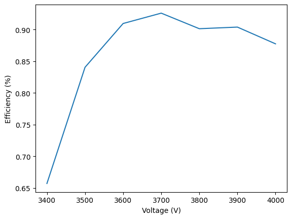

```python
efficients_avg_df.plot(xlabel='Voltage (V)', ylabel='Efficiency (%)')
```

```python
efficients_data_df['epsilon_avg'] = efficients_avg_df

efficients_data_df['sigma_3'] = np.sqrt(efficients_data_df['epsilon_3']*(1-efficients_data_df['epsilon_3'])/events_count_df['events'])

efficients_data_df['sigma_4'] = np.sqrt(efficients_data_df['epsilon_4']*(1-efficients_data_df['epsilon_4'])/events_count_df['events'])

efficients_data_df['sigma_5'] = np.sqrt(efficients_data_df['epsilon_5']*(1-efficients_data_df['epsilon_4'])/events_count_df['events'])

efficients_data_df['sigma_6'] = np.sqrt(efficients_data_df['epsilon_6']*(1-efficients_data_df['epsilon_6'])/events_count_df['events'])
```

```python
efficients_data_df
```

|  | epsilon_3 | epsilon_4 | epsilon_5 | epsilon_6 | epsilon_avg | sigma_3 | sigma_4 | sigma_5 | sigma_6 |
| --- | --- | --- | --- | --- | --- | --- | --- | --- | --- |
| 3400 | 0.5925 | 0.5963 | 0.7720 | 0.6673 | 0.657025 | 0.021244 | 0.021212 | 0.024136 | 0.020371 |
| 3500 | 0.8012 | 0.8270 | 0.9165 | 0.8171 | 0.840450 | 0.017795 | 0.016865 | 0.017754 | 0.017237 |
| 3600 | 0.8748 | 0.9026 | 0.9374 | 0.9235 | 0.909575 | 0.013801 | 0.012365 | 0.012601 | 0.011084 |
| 3700 | 0.9070 | 0.9219 | 0.9462 | 0.9286 | 0.925925 | 0.011837 | 0.010936 | 0.011079 | 0.010495 |
| 3800 | 0.8614 | 0.8961 | 0.9262 | 0.9217 | 0.901350 | 0.013409 | 0.011841 | 0.012039 | 0.010425 |
| 3900 | 0.8677 | 0.9011 | 0.9234 | 0.9234 | 0.903900 | 0.012645 | 0.011141 | 0.011278 | 0.009925 |
| 4000 | 0.8255 | 0.8832 | 0.9134 | 0.8878 | 0.877475 | 0.013749 | 0.011635 | 0.011832 | 0.011433 |

```python
efficients_data_df['w_7'] = 4*efficients_data_df['epsilon_avg']**3*(1-efficients_data_df['epsilon_avg'])
efficients_data_df['w_8'] = efficients_data_df['epsilon_avg']**4

efficients_data_df
```

|  | epsilon_3 | epsilon_4 | epsilon_5 | epsilon_6 | epsilon_avg | sigma_3 | sigma_4 | sigma_5 | sigma_6 | w_7 | w_8 |
| --- | --- | --- | --- | --- | --- | --- | --- | --- | --- | --- | --- |
| 3400 | 0.5925 | 0.5963 | 0.7720 | 0.6673 | 0.657025 | 0.021244 | 0.021212 | 0.024136 | 0.020371 | 0.389106 | 0.186349 |
| 3500 | 0.8012 | 0.8270 | 0.9165 | 0.8171 | 0.840450 | 0.017795 | 0.016865 | 0.017754 | 0.017237 | 0.378872 | 0.498939 |
| 3600 | 0.8748 | 0.9026 | 0.9374 | 0.9235 | 0.909575 | 0.013801 | 0.012365 | 0.012601 | 0.011084 | 0.272185 | 0.684469 |
| 3700 | 0.9070 | 0.9219 | 0.9462 | 0.9286 | 0.925925 | 0.011837 | 0.010936 | 0.011079 | 0.010495 | 0.235212 | 0.735027 |
| 3800 | 0.8614 | 0.8961 | 0.9262 | 0.9217 | 0.901350 | 0.013409 | 0.011841 | 0.012039 | 0.010425 | 0.288960 | 0.660045 |
| 3900 | 0.8677 | 0.9011 | 0.9234 | 0.9234 | 0.903900 | 0.012645 | 0.011141 | 0.011278 | 0.009925 | 0.283886 | 0.667547 |
| 4000 | 0.8255 | 0.8832 | 0.9134 | 0.8878 | 0.877475 | 0.013749 | 0.011635 | 0.011832 | 0.011433 | 0.331123 | 0.592842 |

### Измерение разрешения по Z на космике

Выставить напряжение на камере, соответствующее середине плато эффективности. Про- вести набор событий в течение 0.5–1 часа. Число слоев, по которым строится прямая, задать равным 8 Определить пространственное разрешение по среднему (AVERAGE) ги- стограммы CHI2:

```python
AVERAGE = 45898.16
n = 13806
sigma_z = (AVERAGE/(n-2))**0.5
sigma_z
```

```
1.8234554719027747
```

## Вопросы для контроля

### Какие существуют режимы работы газового цилиндрического счётчика?

Между катодом и анодом создается разность потенциалов, величина которой вы- бирается в зависимости от режима работы счетчика: ионизационная камера, пропорцио- нальный, стримерный, Гейгера–Мюллера, искровой. На рис. 4.1 приведена зависимость тока с анодной проволочки от приложенного напря- жения при облучении счетчика α-частицами и электронами. В области I электроны и ионы первичной ионизации успевают частично рекомбинировать за время дрейфа в зазоре меж- ду катодом и анодом. При увеличении разности потенциалов вероятность рекомбинации уменьшается, что приводит к росту тока. Область I называют областью рекомбинации. В области II процессами рекомбинации можно пренебречь и вся первичная ионизация доходит до электродов, и ток с анодной проволочки не меняется. В этом диапазоне на- пряжений цилиндрический счетчик работает в режиме ионизационной камеры. В области IIIa начинается процесс газового усиления [1]. В результате этого ток с анодной прово- лочки начинает экспоненциально возрастать в зависимости от напряжения на счетчике, при этом сигнал с анодной проволочки пропорционален величине первичной ионизации. В области ограниченной пропорциональности IIIb пропорциональность нарушается из-за пространственного заряда вблизи анодной проволочки. Далее, в зависимости от соста- ва газа, используемого в счетчике, возможны два режима работы. В первом случае из области ограниченной пропорциональности счетчик плавно переходит в режим Гейгера- Мюллера (IV), при этом сигнал с анодной проволочки не зависит от величины первичной ионизации. Указанием на начало области Гейгера-Мюллера можно считать то обстоятель- ство, что величина импульса для частиц с разной ионизирующей способностью, таких как α- и β-частицы, становится одинаковой. Во втором случае при увеличении напряжения наблюдается скачкообразное увеличение амплитуды сигнала с анодной проволочки и его дальнейший экспоненциальный рост. При этом зависимость амплитуды сигнала с анодной проволочки от величины первичной ионизации и типа частицы исчезает. Этот режим на- зывается стримерным — область V. При дальнейшем увеличении напряжения в счетчике загорается разряд или происходит искровой пробой — область VI.

[figure not shown]

### Какой механизм самогасящегося стриммерного разряда и в чем его отличие от гейгеровского?

Далее, в зависимости от соста- ва газа, используемого в счетчике, возможны два режима работы. В первом случае из области ограниченной пропорциональности счетчик плавно переходит в режим Гейгера- Мюллера (IV), при этом сигнал с анодной проволочки не зависит от величины первичной ионизации. Указанием на начало области Гейгера-Мюллера можно считать то обстоятель- ство, что величина импульса для частиц с разной ионизирующей способностью, таких как α- и β-частицы, становится одинаковой. Во втором случае при увеличении напряжения наблюдается скачкообразное увеличение амплитуды сигнала с анодной проволочки и его дальнейший экспоненциальный рост. При этом зависимость амплитуды сигнала с анодной проволочки от величины первичной ионизации и типа частицы исчезает. Этот режим на- зывается стримерным — область V. При дальнейшем увеличении напряжения в счетчике загорается разряд или происходит искровой пробой — область VI.

### Какие особенности работы газового цилиндрического счётчика в ограниченном стримерном режиме.

Во втором случае при увеличении напряжения наблюдается скачкообразное увеличение амплитуды сигнала с анодной проволочки и его дальнейший экспоненциальный рост. При этом зависимость амплитуды сигнала с анодной проволочки от величины первичной ионизации и типа частицы исчезает. Этот режим на- зывается стримерным — область V. При дальнейшем увеличении напряжения в счетчике загорается разряд или происходит искровой пробой — область VI.

### Какие способы измерения продольной координаты в газовом цилиндрическом счётчике вы знаете?

Часто, кроме самого факта прохождения частицы, требуется еще измерить координату прохождения частицы через детектор. В настоящее время развито много методик для определения координаты в стримерных трубках. К наиболее известным можно отнести следующие:

- определение координаты в режиме ДА-НЕТ (по номеру сработавшей трубки);
- определение координаты вдоль проволочки по центру тяжести наведенного заряда на катодные полоски, расположенные перпендикулярно к проволочке;
- определение координаты вдоль проволочки по делению заряда на разных концах трубки;
- определение координаты вдоль проволочки по разности времен прихода сигнала на разные концы трубки;
- определение координаты в перпендикулярном к проволочке направлении по времени дрейфа ионизации до проволочки;

Из теории вероятностей.

Из мат.статистики.